# WR Error Rates

Fátima S. Barreiro

October 8, 2020

Load required libraries

```r
library(ggplot2)
library(cowplot)
library(ggrepel)
library(reshape2)
library(dplyr)
library(tidyverse)
library(data.table)
require(scales)
library(ggpubr)
library(tidyr)
library(PairedData)
library(gridExtra)
```

Reading in file containing metadata and genomic diversity metrics

```r
data = read.table("WR_ErrorRates_P9109_110best_BRout.Est.txt", header=T, fill=T, stringsAsFactors=T, fileEncoding="latin1")
```

Reading in file containing metadata and genomic diversity metrics

```r
metadata = read.csv("WR_TableS1_v4.csv", h=T, fill=T, stringsAsFactors=T, fileEncoding="latin1")
```

### Visualizing the error rates per sample

Bind the sample lab_IDs to the error rates dataframe so each row of error rates can be assigned to its corresponding sample

```r
smalldata = data[1:52,]
IDs = as.data.frame(metadata$lab_ID)
colnames(IDs) = "ID"
smalldata = cbind(smalldata, IDs)
head(smalldata)
```

```
##              CtoA        GtoA         TtoA         AtoC         GtoC
## ind1 0.0003173785 0.005536565 0.0002045566 0.0000000001 9.089459e-05
## ind2 0.0010126744 0.009694966 0.0008617039 0.0006407241 8.397353e-04
## ind3 0.0013804670 0.010545274 0.0011689044 0.0010110926 1.225025e-03
## ind4 0.0013136989 0.011943179 0.0011161401 0.0009065097 1.096088e-03
## ind5 0.0001203947 0.008611012 0.0001991112 0.0000000001 8.194838e-05
## ind6 0.0001696639 0.008898154 0.0002035320 0.0000000001 1.184924e-04
##              TtoC         AtoG         CtoG         TtoG         AtoT
## ind1 0.0003201323 0.0003105401 8.971959e-05 1.000000e-10 0.0002011665
## ind2 0.0021024263 0.0020423028 8.266781e-04 6.543095e-04 0.0008515711
## ind3 0.0033464369 0.0032915911 1.214768e-03 1.024342e-03 0.0011590407
## ind4 0.0029764018 0.0029365264 1.090880e-03 9.169067e-04 0.0011098560
## ind5 0.0002409797 0.0002328196 8.255060e-05 1.000000e-10 0.0001971943
## ind6 0.0003826093 0.0003670388 1.169708e-04 2.476791e-07 0.0002013655
##             CtoT         GtoT         ID
## ind1 0.005520022 0.0003163733 mwr_TG0449
## ind2 0.009611653 0.0010029998 mwr_TG0450
## ind3 0.010456425 0.0013692046 mwr_TG0451
## ind4 0.011869221 0.0013037469 mwr_TG0452
## ind5 0.008598922 0.0001169495 mwr_TG0453
## ind6 0.008878344 0.0001668296 mwr_TG0454
```

Melt the data to facilitate plotting

```r
smalldataM = reshape2::melt(smalldata)
head(smalldataM)
```

```
##           ID variable        value
## 1 mwr_TG0449     CtoA 0.0003173785
## 2 mwr_TG0450     CtoA 0.0010126744
## 3 mwr_TG0451     CtoA 0.0013804670
## 4 mwr_TG0452     CtoA 0.0013136989
## 5 mwr_TG0453     CtoA 0.0001203947
## 6 mwr_TG0454     CtoA 0.0001696639
```

Visualizing the error rates (all types) per sample

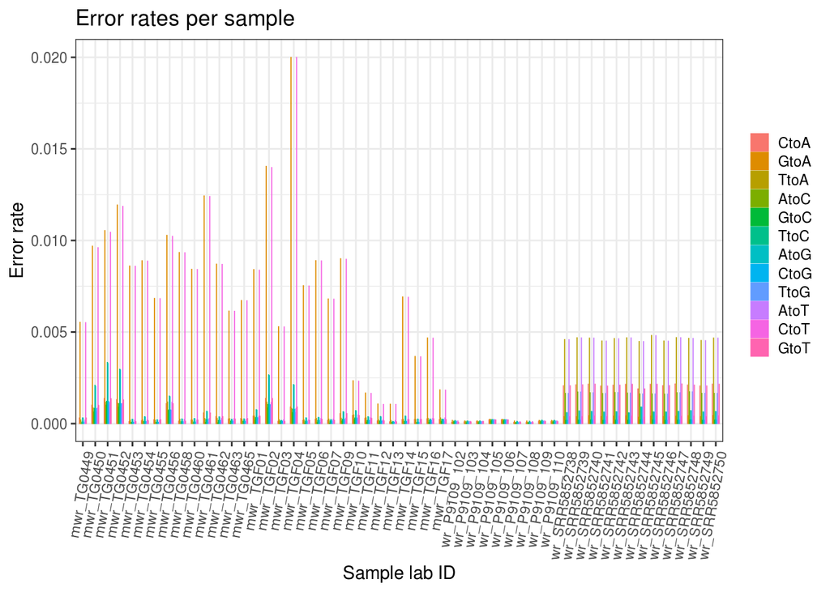

```r
E = ggplot(smalldataM, aes(ID, value, fill=variable, colour=variable)) + geom_bar(position = position_dodge(0.6), stat = "identity", width=0.4, size=0.2) + theme_bw() +
  theme(axis.text.x=element_text(angle=80, hjust=1), legend.key.size= unit(4, "mm"), legend.title=element_blank()) +
  ylab("Error rate") + xlab("Sample lab ID") +
  ggtitle("Error rates per sample")

E
```

Save the plot

### Correlations between error rates and estimates of heterozygosity

Parse the dataframe: add the heterozygosity estimates from the metadata. In this case I used the estimates with GL2 and filtering sites below 3x

```r
HET3x = metadata$gw_het_GL2_3x
HET5x = metadata$gw_het_GL2_5x

smalldataH = cbind(smalldata, HET3x, HET5x)
head(smalldataH)
```

```
##              CtoA        GtoA         TtoA         AtoC         GtoC
## ind1 0.0003173785 0.005536565 0.0002045566 0.0000000001 9.089459e-05
## ind2 0.0010126744 0.009694966 0.0008617039 0.0006407241 8.397353e-04
## ind3 0.0013804670 0.010545274 0.0011689044 0.0010110926 1.225025e-03
## ind4 0.0013136989 0.011943179 0.0011161401 0.0009065097 1.096088e-03
## ind5 0.0001203947 0.008611012 0.0001991112 0.0000000001 8.194838e-05
## ind6 0.0001696639 0.008898154 0.0002035320 0.0000000001 1.184924e-04
##              TtoC         AtoG         CtoG         TtoG         AtoT
## ind1 0.0003201323 0.0003105401 8.971959e-05 1.000000e-10 0.0002011665
## ind2 0.0021024263 0.0020423028 8.266781e-04 6.543095e-04 0.0008515711
## ind3 0.0033464369 0.0032915911 1.214768e-03 1.024342e-03 0.0011590407
## ind4 0.0029764018 0.0029365264 1.090880e-03 9.169067e-04 0.0011098560
## ind5 0.0002409797 0.0002328196 8.255060e-05 1.000000e-10 0.0001971943
## ind6 0.0003826093 0.0003670388 1.169708e-04 2.476791e-07 0.0002013655
##             CtoT         GtoT         ID      HET3x      HET5x
## ind1 0.005520022 0.0003163733 mwr_TG0449 0.00013056 0.00013415
## ind2 0.009611653 0.0010029998 mwr_TG0450 0.00017182 0.00034522
## ind3 0.010456425 0.0013692046 mwr_TG0451 0.00018862 0.00032295
## ind4 0.011869221 0.0013037469 mwr_TG0452 0.00020383 0.00025049
## ind5 0.008598922 0.0001169495 mwr_TG0453 0.00020781 0.00020857
## ind6 0.008878344 0.0001668296 mwr_TG0454 0.00019078 0.00020005
```

Create a function to run and visualize linear regressions

```r
correlate_vars = function(dataframe, het_var, error_var, ID) {
  plot = ggscatter(dataframe, x = het_var, y = error_var, label = ID,
          add = "reg.line", conf.int = TRUE,
          cor.coef = TRUE, cor.method = "pearson")
  return(plot)
  print(plot)
}
```

Use the function to visualise correlation plots of every error rate with the two Het estimates chosen

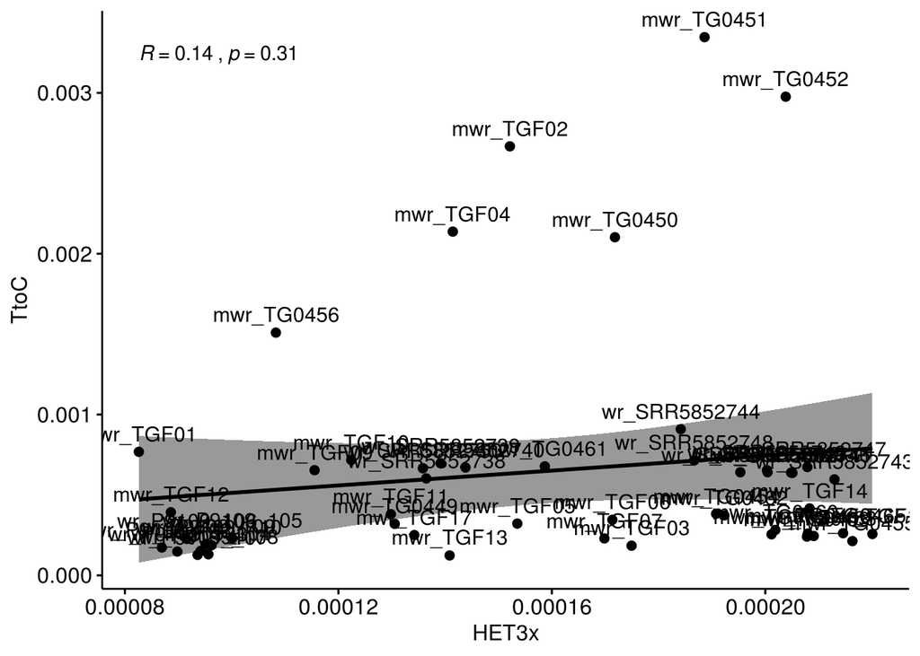

```r
correlate_vars(smalldataH, "HET3x", "TtoC", "ID")
```

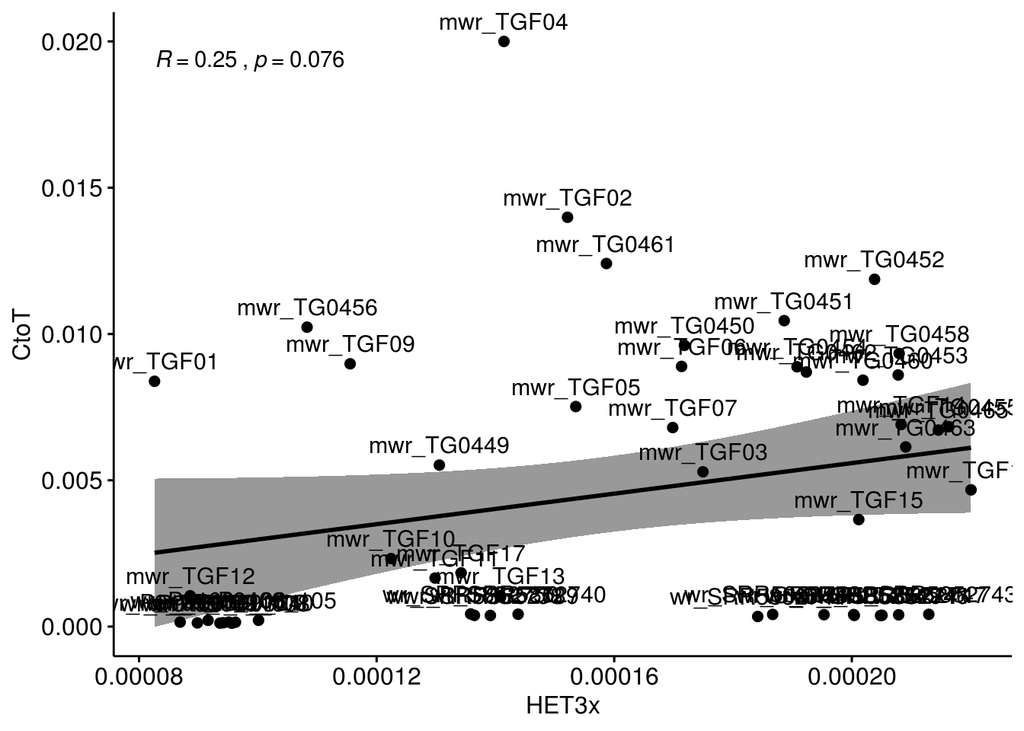

```r
correlate_vars(smalldataH, "HET3x", "CtoT", "ID")
```

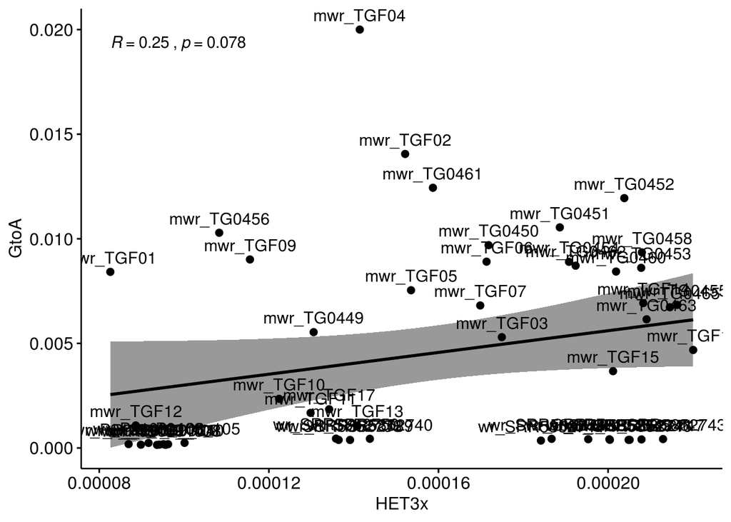

```r
correlate_vars(smalldataH, "HET3x", "GtoA", "ID")
```

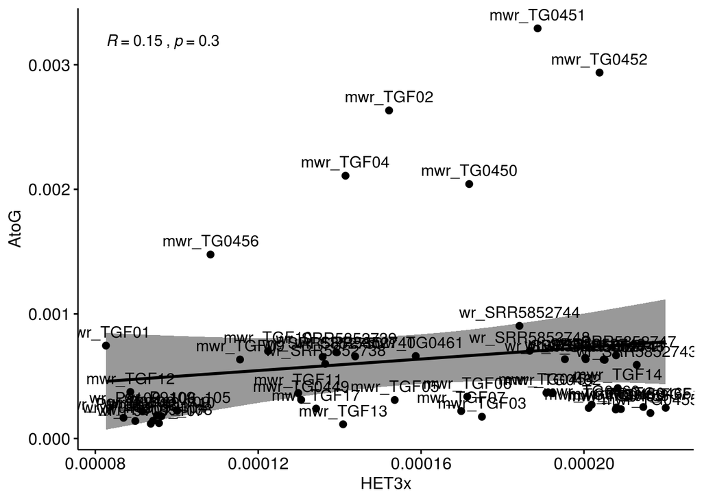

```r
correlate_vars(smalldataH, "HET3x", "AtoG", "ID")
```

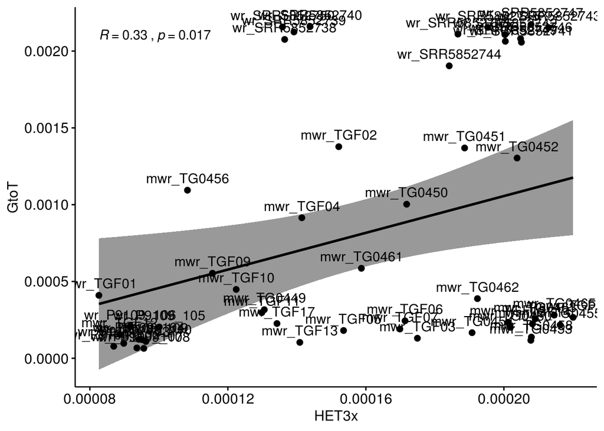

```r
correlate_vars(smalldataH, "HET3x", "GtoT", "ID")
```

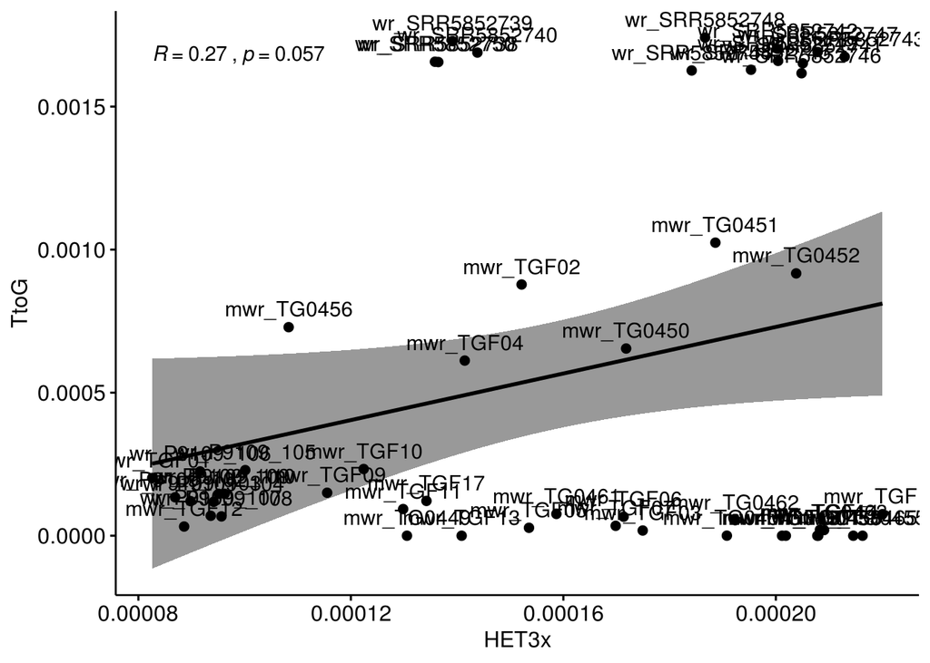

```r
correlate_vars(smalldataH, "HET3x", "TtoG", "ID")
```

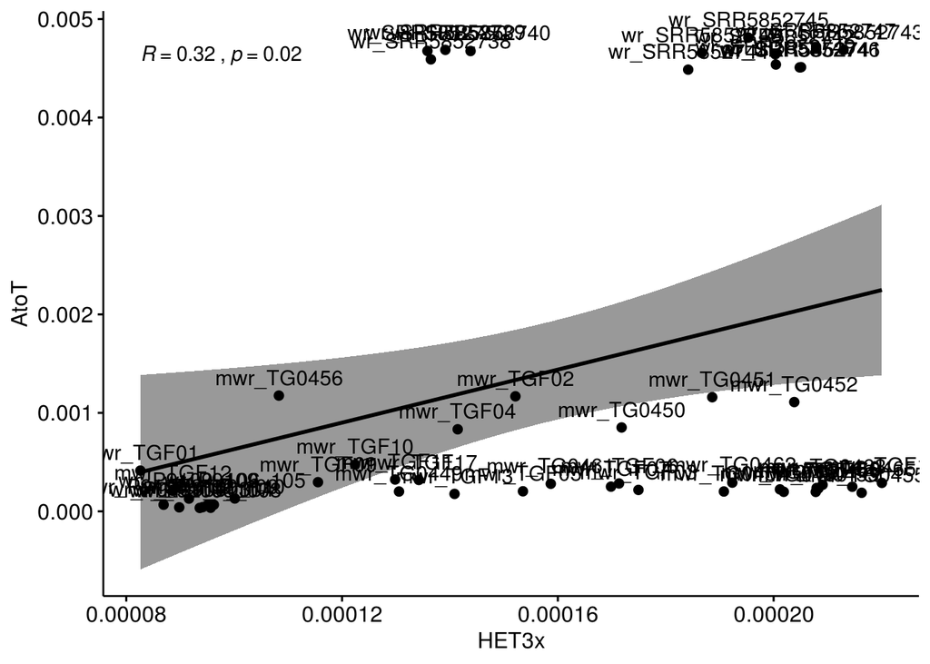

```r
correlate_vars(smalldataH, "HET3x", "AtoT", "ID")
```

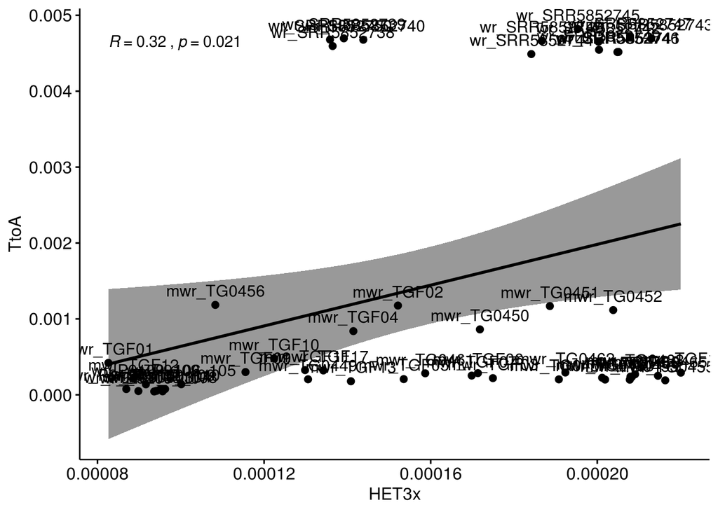

```r
correlate_vars(smalldataH, "HET3x", "TtoA", "ID")
```

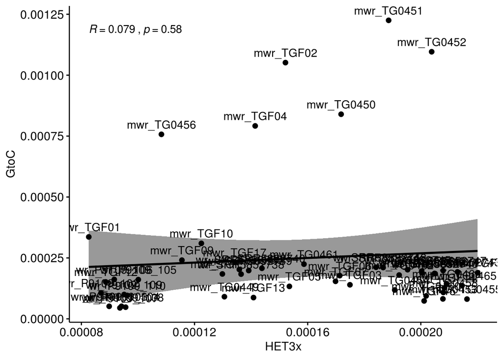

```r
correlate_vars(smalldataH, "HET3x", "GtoC", "ID")
```

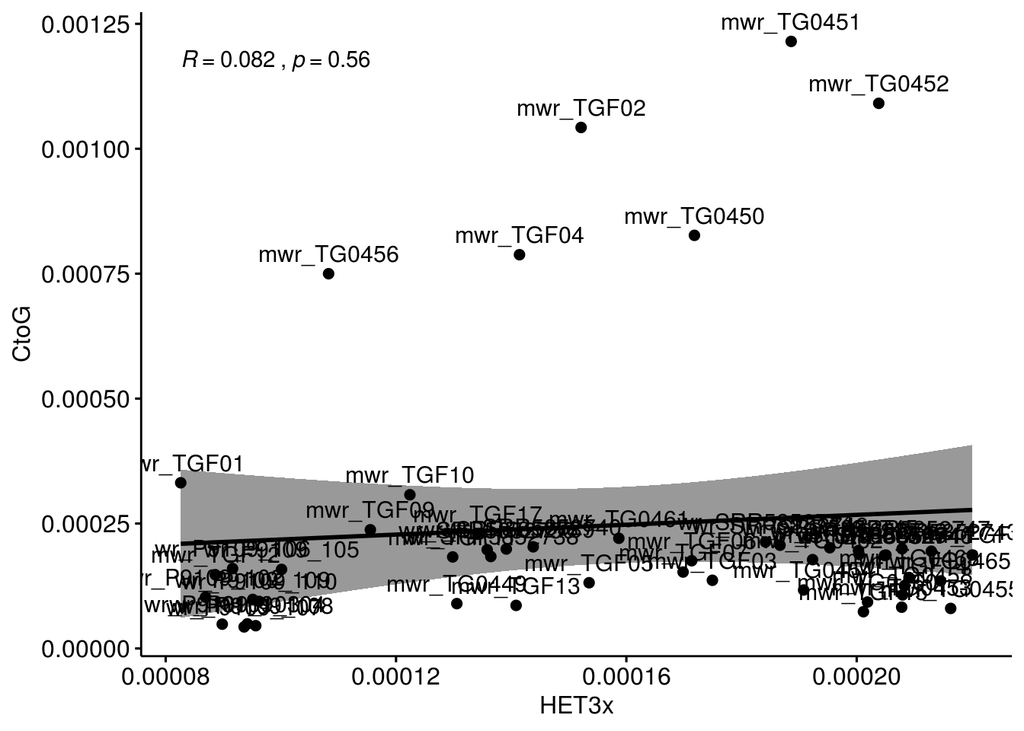

```r
correlate_vars(smalldataH, "HET3x", "CtoG", "ID")
```

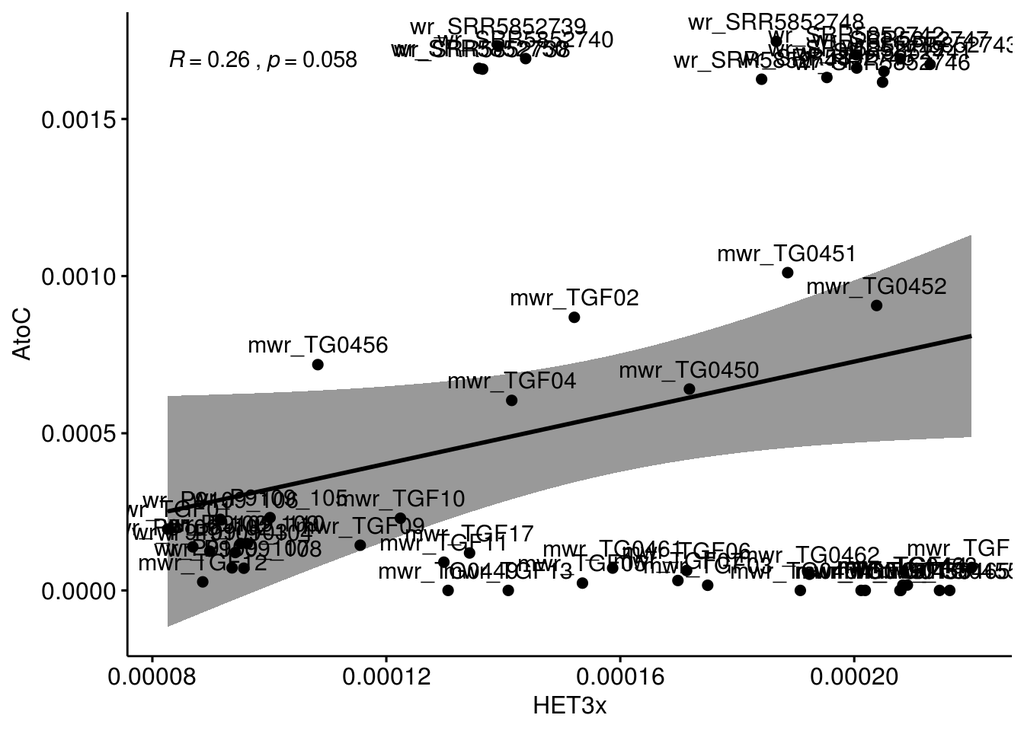

```r
correlate_vars(smalldataH, "HET3x", "AtoC", "ID")
```

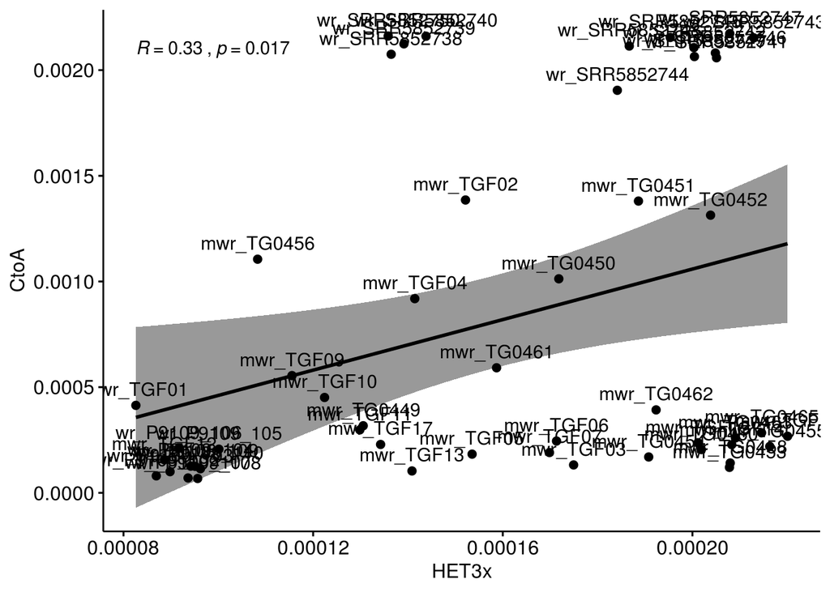

```r
correlate_vars(smalldataH, "HET3x", "CtoA", "ID")
```

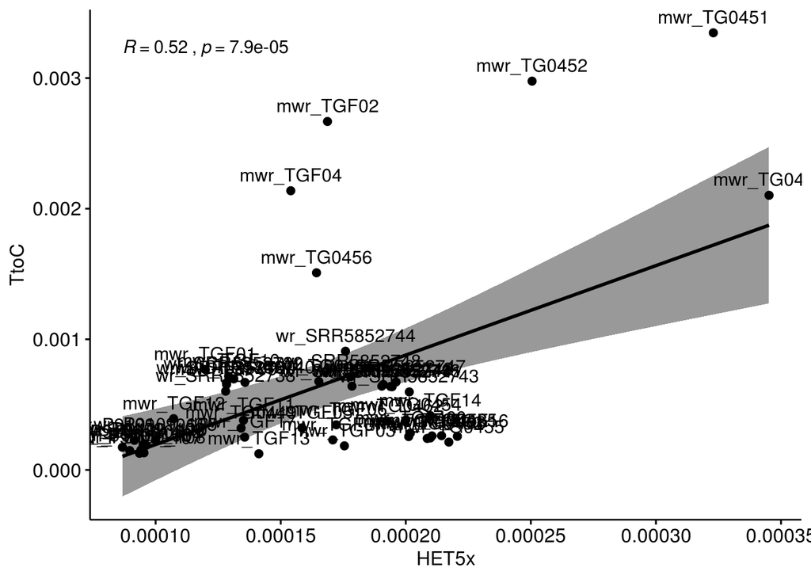

```r
correlate_vars(smalldataH, "HET5x", "TtoC", "ID")
```

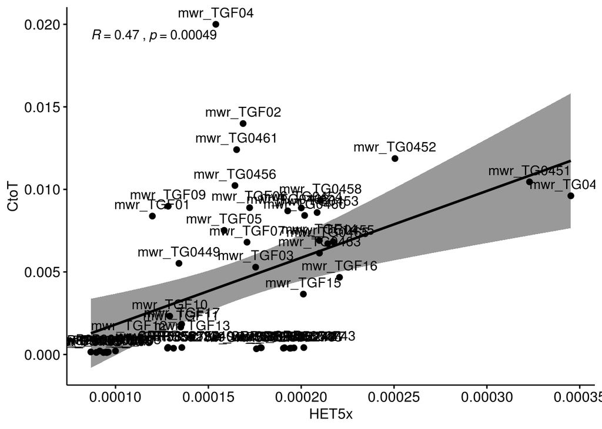

```r
correlate_vars(smalldataH, "HET5x", "CtoT", "ID")
```

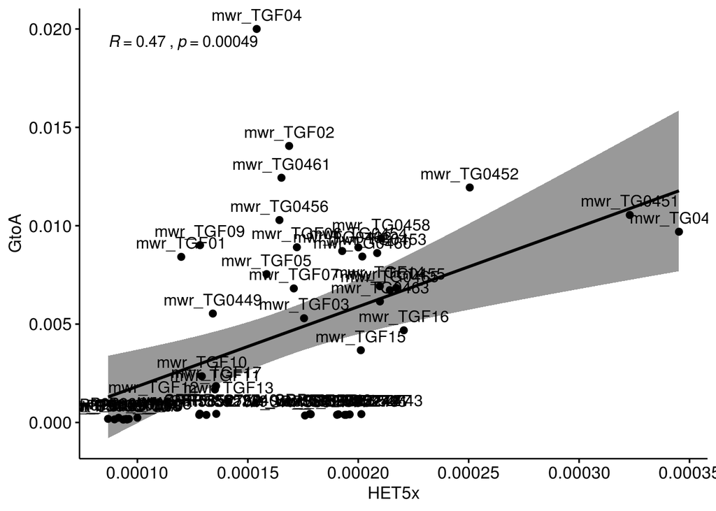

```r
correlate_vars(smalldataH, "HET5x", "GtoA", "ID")
```

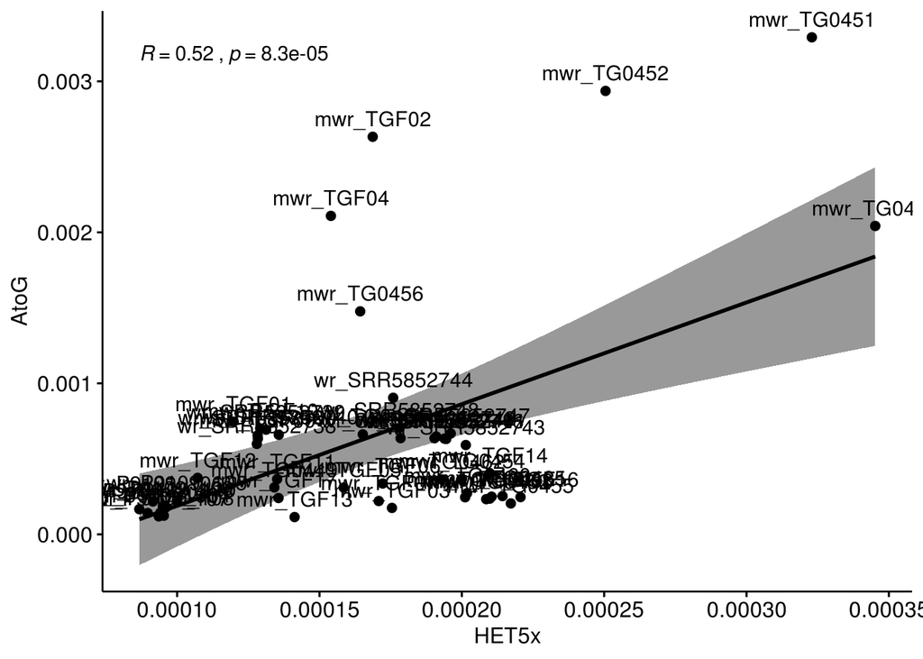

```r
correlate_vars(smalldataH, "HET5x", "AtoG", "ID")
```

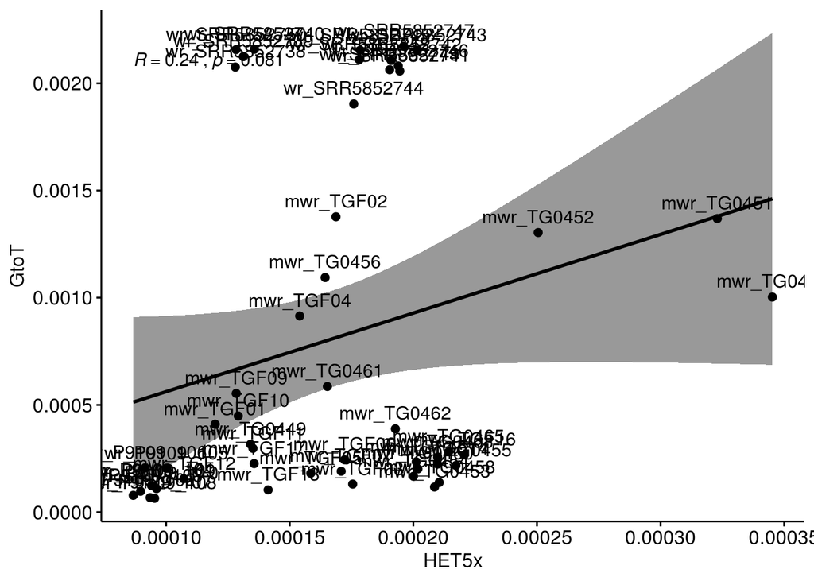

```r
correlate_vars(smalldataH, "HET5x", "GtoT", "ID")
```

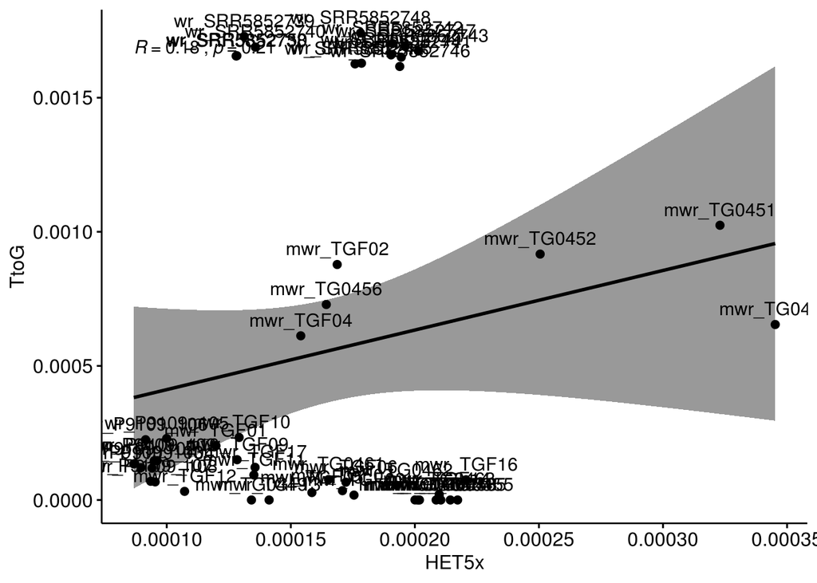

```r
correlate_vars(smalldataH, "HET5x", "TtoG", "ID")
```

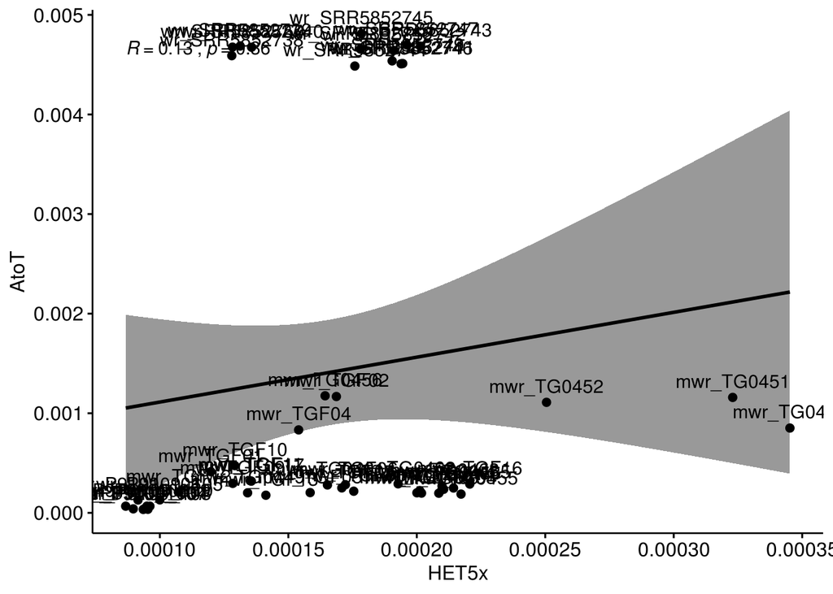

```r
correlate_vars(smalldataH, "HET5x", "AtoT", "ID")
```

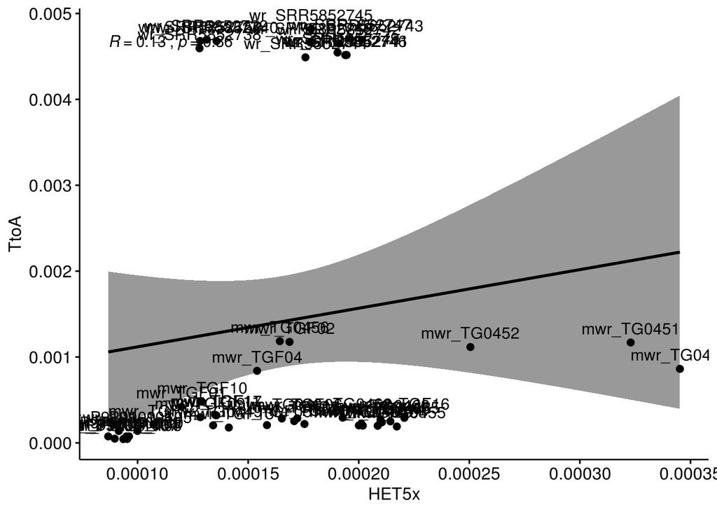

```r
correlate_vars(smalldataH, "HET5x", "TtoA", "ID")
```

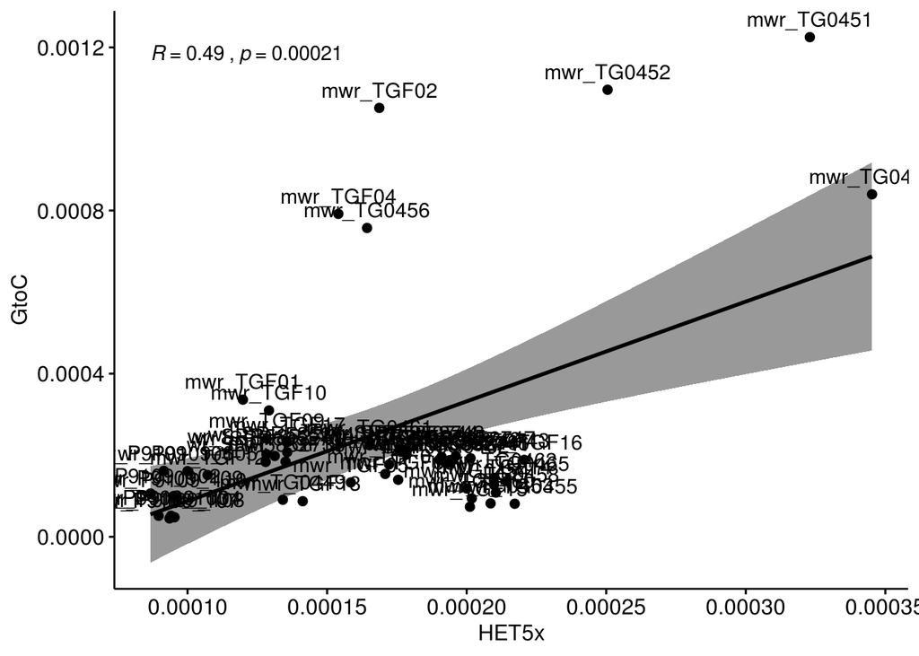

```r
correlate_vars(smalldataH, "HET5x", "GtoC", "ID")
```

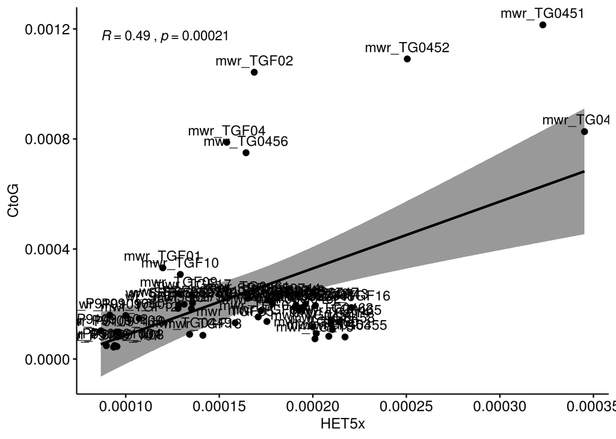

```r
correlate_vars(smalldataH, "HET5x", "CtoG", "ID")
```

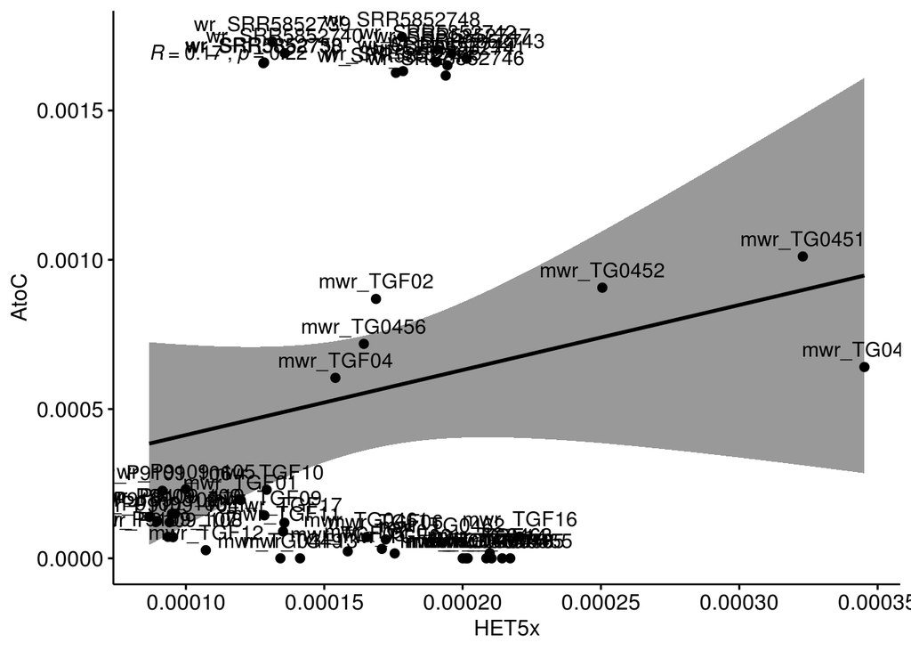

```r
correlate_vars(smalldataH, "HET5x", "AtoC", "ID")
```

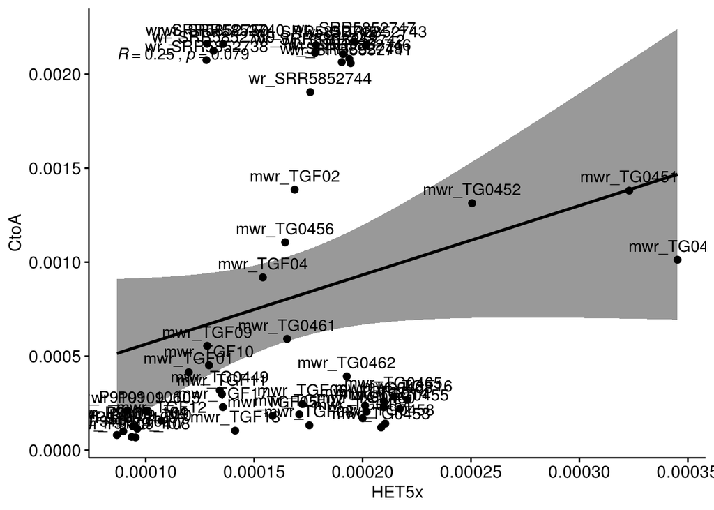

```r
correlate_vars(smalldataH, "HET5x", "CtoA", "ID")
```

The following error rates correlate significantly with Het estimates: G-to-T T-to-G (marginally) A-to-T T-to-A A-to-C (marginally) C-to-A

This is probably due to the samples in the SRR which show higher error rates at transversion sites than the remaining batches.

On the other hand, Het estimates with 5x filtering seem to correlate with transition error rates too, however this seems to be driven by the low depth of coverage samples that will be excluded (TG0450, TG0451, TG0456, TGF01).

### Calculate a transversion composite error rate with which to correct the Het estimates to buffer the effect of the SRR batch

Calculate a composite error rate at Tv sites by summing up all error rates per row

```r
smalldata %>%
  dplyr::select(GtoT, TtoG, AtoT, TtoA, AtoC, CtoA) %>%
  rowSums(na.rm=TRUE) -> smalldata$ErTv

head(smalldata)
```

```
##              CtoA        GtoA         TtoA         AtoC         GtoC
## ind1 0.0003173785 0.005536565 0.0002045566 0.0000000001 9.089459e-05
## ind2 0.0010126744 0.009694966 0.0008617039 0.0006407241 8.397353e-04
## ind3 0.0013804670 0.010545274 0.0011689044 0.0010110926 1.225025e-03
## ind4 0.0013136989 0.011943179 0.0011161401 0.0009065097 1.096088e-03
## ind5 0.0001203947 0.008611012 0.0001991112 0.0000000001 8.194838e-05
## ind6 0.0001696639 0.008898154 0.0002035320 0.0000000001 1.184924e-04
##              TtoC         AtoG         CtoG         TtoG         AtoT
## ind1 0.0003201323 0.0003105401 8.971959e-05 1.000000e-10 0.0002011665
## ind2 0.0021024263 0.0020423028 8.266781e-04 6.543095e-04 0.0008515711
## ind3 0.0033464369 0.0032915911 1.214768e-03 1.024342e-03 0.0011590407
## ind4 0.0029764018 0.0029365264 1.090880e-03 9.169067e-04 0.0011098560
## ind5 0.0002409797 0.0002328196 8.255060e-05 1.000000e-10 0.0001971943
## ind6 0.0003826093 0.0003670388 1.169708e-04 2.476791e-07 0.0002013655
##             CtoT         GtoT         ID         ErTv
## ind1 0.005520022 0.0003163733 mwr_TG0449 0.0010394751
## ind2 0.009611653 0.0010029998 mwr_TG0450 0.0050239828
## ind3 0.010456425 0.0013692046 mwr_TG0451 0.0071130513
## ind4 0.011869221 0.0013037469 mwr_TG0452 0.0066668584
## ind5 0.008598922 0.0001169495 mwr_TG0453 0.0006336500
## ind6 0.008878344 0.0001668296 mwr_TG0454 0.0007416389
```

Save these error rates (single and composite) as a separate file

```r
write.table(smalldata, file="WR_Errors_ErTv.csv", row.names=F, col.names=T, sep=",")
```

### Calculate the corrected het by operating with the composite error rate and the het estimate

```r
smalldataHc = cbind(smalldataH, smalldata$ErTv)
head(smalldataHc)
```

```
##              CtoA        GtoA         TtoA         AtoC         GtoC
## ind1 0.0003173785 0.005536565 0.0002045566 0.0000000001 9.089459e-05
## ind2 0.0010126744 0.009694966 0.0008617039 0.0006407241 8.397353e-04
## ind3 0.0013804670 0.010545274 0.0011689044 0.0010110926 1.225025e-03
## ind4 0.0013136989 0.011943179 0.0011161401 0.0009065097 1.096088e-03
## ind5 0.0001203947 0.008611012 0.0001991112 0.0000000001 8.194838e-05
## ind6 0.0001696639 0.008898154 0.0002035320 0.0000000001 1.184924e-04
##              TtoC         AtoG         CtoG         TtoG         AtoT
## ind1 0.0003201323 0.0003105401 8.971959e-05 1.000000e-10 0.0002011665
## ind2 0.0021024263 0.0020423028 8.266781e-04 6.543095e-04 0.0008515711
## ind3 0.0033464369 0.0032915911 1.214768e-03 1.024342e-03 0.0011590407
## ind4 0.0029764018 0.0029365264 1.090880e-03 9.169067e-04 0.0011098560
## ind5 0.0002409797 0.0002328196 8.255060e-05 1.000000e-10 0.0001971943
## ind6 0.0003826093 0.0003670388 1.169708e-04 2.476791e-07 0.0002013655
##             CtoT         GtoT         ID      HET3x      HET5x smalldata$ErTv
## ind1 0.005520022 0.0003163733 mwr_TG0449 0.00013056 0.00013415   0.0010394751
## ind2 0.009611653 0.0010029998 mwr_TG0450 0.00017182 0.00034522   0.0050239828
## ind3 0.010456425 0.0013692046 mwr_TG0451 0.00018862 0.00032295   0.0071130513
## ind4 0.011869221 0.0013037469 mwr_TG0452 0.00020383 0.00025049   0.0066668584
## ind5 0.008598922 0.0001169495 mwr_TG0453 0.00020781 0.00020857   0.0006336500
## ind6 0.008878344 0.0001668296 mwr_TG0454 0.00019078 0.00020005   0.0007416389
```

```r
# subtract from the Het estimate the excess driven by transversion error rates
smalldataHc = smalldataHc %>%
  mutate(HET3x_corrected = HET3x-(HET3x*smalldata$ErTv), HET5x_corrected = HET5x-(HET5x*smalldata$ErTv) )
```

Visualise the new het estimates

```r
tinydataHc = smalldataHc %>%
  dplyr::select(ID, HET3x, HET5x, HET3x_corrected, HET5x_corrected)

tinydataHc = reshape2::melt(tinydataHc)
```

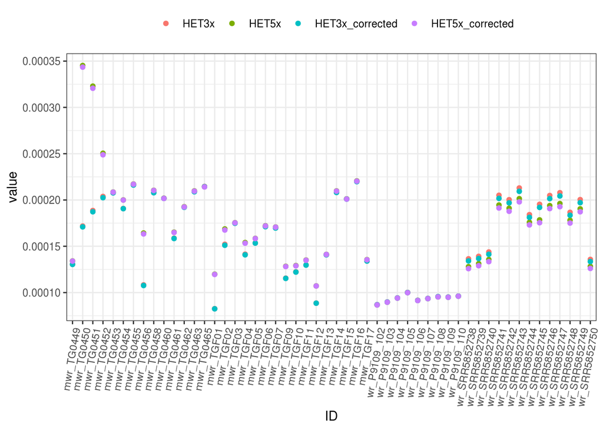

```r
P = ggplot(tinydataHc, aes(ID, value, colour=variable)) + geom_point() + theme_bw() +
  theme(axis.text.x=element_text(angle=80, hjust=1), legend.title = element_blank(), legend.position = "top")

P
```